# Final_ss4370

Q3. Write code to find a 3-configuration on n points. Be clear as to your method and approach, and any math that you do to formulate it.

```python
import numpy as np
import math
import matplotlib.pyplot as plt
from matplotlib.pyplot import figure
```

```python
#projecting the point back to the constraint set. Here, that is a unit circle.
def projected_component(x, r=1):
    return np.dot(x, min((r/np.linalg.norm(x)), 1))
```

```python
#gradient descent
def gd(x,d,alpha):
    return np.add(x, np.dot(alpha,d))
```

```python
#derivative of the F(x) function, solved in paper.
def derivative(x, ind, n):
    s = 0
    for i in range(n):
        s += np.subtract(x[ind], x[i])

    return 2*s
```

```python
#starts with random vectors and approaches optimal configuration using projected gradient descent.
def find_n_points(n, d):
    X = np.random.rand(n,d)
    alpha = 0.001
    for i in range(50000):
        temp = []
        for j in range(n):
            temp.append(projected_component(gd(X[j], alpha, derivative(X,j, n))))
        X = temp
    return X
```

```python
#calculates the distance between one point to all other points on the sphere.
def distance_between_points(x):
    temp = []
    for i in range(len(x)):
        for j in range(i+1,len(x)):
            temp.append(np.linalg.norm(np.subtract(x[i],x[j])))
    return temp
```

```python
x = find_n_points(3,3)
```

```python
for i in range(len(x)):
    print(np.linalg.norm(x[i]))
```

```
1.0
1.0
0.9999999999999999
```

```python
y = distance_between_points(x)
for i in y:
    print(i)
```

```
1.7320508075688656
1.7320508075688885
1.7320508075688779
```

Q4. Find a three-point 3-configuration. Show that the configuration is flat.

```python
#finding equation of the plane by finding the normal trough cross product.
v1 = x[2] - x[0]
v2 = x[1] - x[0]
normal = np.cross(v1, v2)
a, b, c = normal
d = np.dot(normal, x[2])
print(normal,d)
for i in range(len(x)):
    print(np.dot(normal,x[i]))
```

```
[0.99727987 0.65929527 2.30667783] 4.6629367034256575e-15
4.746203430272544e-15
4.773959005888173e-15
4.6629367034256575e-15
```

They all exist in the same plane. Since, they satisfy the plane equation.

Q5. Find a four-point 3-configuration. Show that the configuration isn’t flat.

```python
x = find_n_points(4,3)
```

```python
for i in range(len(x)):
    print(np.linalg.norm(x[i]))
```

```
1.0
0.9999999999999999
1.0
1.0
```

```python
y = distance_between_points(x)
for i in y:
    print(i)
```

```
1.085922038612683
1.8163266082180598
1.8766275545068407
1.8766275545068372
1.8163266082180625
1.0859220386127102
```

```python
v1 = x[2] - x[0]
v2 = x[1] - x[0]
normal = np.cross(v1, v2)
a, b, c = normal
d = np.dot(normal, x[2])
print(normal,d)

for i in range(len(x)):
    print(np.dot(normal,x[i]))
```

```
[ 1.05009292 -0.37343529 -1.5554512 ] -0.48622369002623844
-0.48622369002623833
-0.48622369002623855
-0.48622369002623844
1.4586710700786854
```

The fourth point is on a parallel plane because it doesn't satisfy the plane equation given by the other 3 points.

Q6. Show that for any three- or four-point 3-configuration, the set of distances and angles to the other points is the same regardless of what point you measure from. We say the configuration is regular. How did you do it? What shapes do these configurations correspond to?

```python
#computes angles between all the vectors in a given list of vectors. It uses the dotproduct to find the angle.
def compute_angle(vectors):
    angle = []
    for vector in vectors:
        temp = []
        for i in range(len(vector)):
            for j in range(len(vector)):
                if i!=j:
                    u,v = vector[j],vector[i]
                    temp.append(round(np.arccos(np.dot(u,v)/((np.linalg.norm(u))*(np.linalg.norm(v))))/math.pi*180,3))
        angle.append(temp)
    return angle
```

```python
#finds the vectors using 2 of the given points from the find_n_point.
def compute_distance_angle(x):
    distance=[]
    vector = []
    for i in range(len(x)):
        temp = []
        temp2 = []
        for j in range(len(x)):
            if i!=j:
                temp2.append(round(np.linalg.norm(x[i] - x[j]),3))
                temp.append(x[i]-x[j])
        vector.append(temp)
        distance.append(temp2)
    return distance,compute_angle(vector)
```

```python
x = find_n_points(3,3)
```

```python
compute_distance_angle(x)
```

```
([[1.732, 1.732], [1.732, 1.732], [1.732, 1.732]],
 [[60.0, 60.0], [60.0, 60.0], [60.0, 60.0]])
```

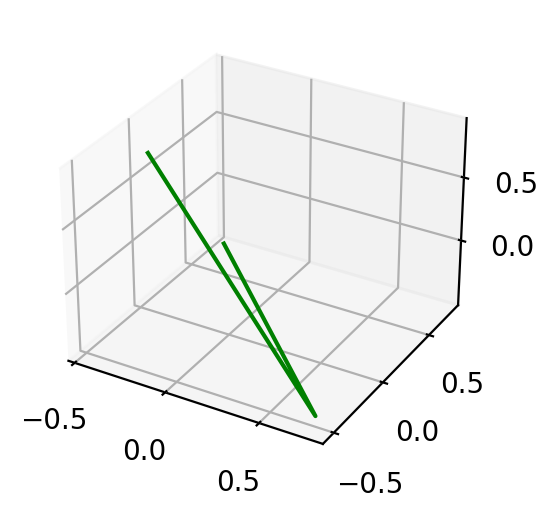

```python
#plotting all the points on a 3D plot.
coordinates = np.array(x)
X_ax= coordinates[:,0]
Y_ax = coordinates[:,1]
Z_ax = coordinates[:,2]
fig = plt.figure()
figure(figsize=(3, 3), dpi=200)
ax = plt.axes(projection ='3d')
ax.plot3D(X_ax, Y_ax, Z_ax, 'green')
plt.show()
```

3 point 3 configuration forms an equilateral triangle with 60 degrees and equal sides.

```python
x = find_n_points(4,3)
```

```python
compute_distance_angle(x)
```

```
([[1.739, 1.963, 1.058],
  [1.739, 1.058, 1.963],
  [1.963, 1.058, 1.739],
  [1.058, 1.963, 1.739]],
 [[32.502, 85.483, 32.502, 62.015, 85.483, 62.015],
  [85.483, 32.502, 85.483, 62.015, 32.502, 62.015],
  [62.015, 32.502, 62.015, 85.483, 32.502, 85.483],
  [62.015, 85.483, 62.015, 32.502, 85.483, 32.502]])
```

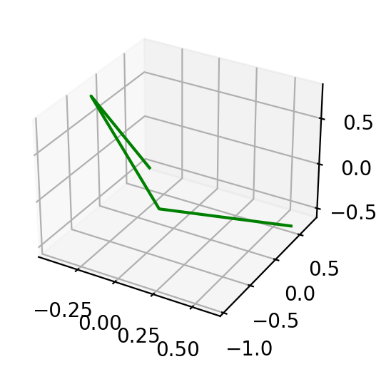

```python
coordinates = np.array(x)
X_ax= coordinates[:,0]
Y_ax = coordinates[:,1]
Z_ax = coordinates[:,2]
fig = plt.figure()
figure(figsize=(3, 3), dpi=200)
ax = plt.axes(projection ='3d')
ax.plot3D(X_ax, Y_ax, Z_ax, 'green')
plt.show()
```

The figure looks like a twisted rectangle where 3 points are on aplane and the last point is on another plane.

Yes the are 3 and 4 point configurations are regular.

Q7. Find five-point 3-configurations. What can you say about the sets of distances and angles between the points? How many distinct five-point configurations can you find?

```python
x = find_n_points(5,3)
compute_distance_angle(x)
```

```
([[1.902, 1.995, 1.018, 1.168],
  [1.902, 0.726, 1.65, 1.771],
  [1.995, 0.726, 1.766, 1.541],
  [1.018, 1.65, 1.766, 1.768],
  [1.168, 1.771, 1.541, 1.768]],
 [[21.294,
   60.057,
   65.436,
   21.294,
   62.125,
   50.425,
   60.057,
   62.125,
   107.667,
   65.436,
   50.425,
   107.667],
  [86.598,
   32.341,
   36.884,
   86.598,
   86.884,
   59.966,
   32.341,
   86.884,
   62.121,
   36.884,
   59.966,
   62.121],
  [72.107,
   30.653,
   35.758,
   72.107,
   68.882,
   95.974,
   30.653,
   68.882,
   64.204,
   35.758,
   95.974,
```

[output cut: 10 more lines]

```
   39.039,
   62.303,
   51.723],
  [77.68,
   93.817,
   33.294,
   77.68,
   24.061,
   55.576,
   93.817,
   24.061,
   64.073,
   33.294,
   55.576,
   64.073]])
```

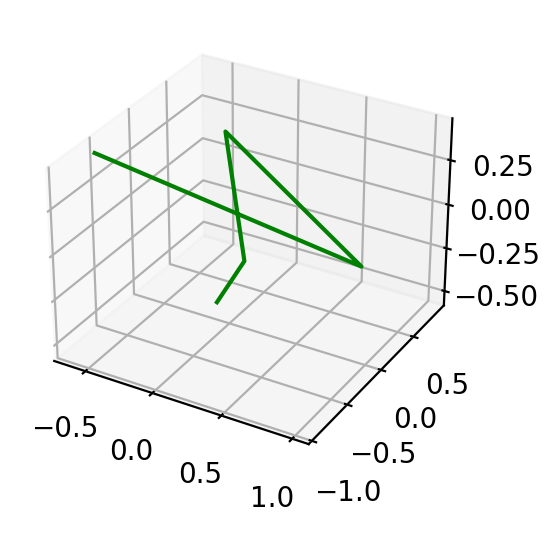

```python
coordinates = np.array(x)
X_ax= coordinates[:,0]
Y_ax = coordinates[:,1]
Z_ax = coordinates[:,2]
fig = plt.figure()
figure(figsize=(3, 3), dpi=200)
ax = plt.axes(projection ='3d')
ax.plot3D(X_ax, Y_ax, Z_ax, 'green')
plt.show()
```

There is no correlation between the distances and angles of the 5 point 3 configuration. There is no particular shape it exists in.

Q8. For a Goncharov d-configuration on n points, call it k-regular if it has k many ‘classes’ of points, based on sets of distances and angles to the other points when measured from any point (essentially, k different views of the other points are possible, depending on which point you stand on). For n = 2, 3, 4, . . . , 20, characterize all the 3-configurations you can find in terms of their regularity.

```python
d = 3
#loop till 20 points and check for the linear independence of the matrix of all the points which would tell us about the dimensions they are restricted to.
for n in range(2,21):
    x = find_n_points(n,d)
    distance,angle = compute_distance_angle(x)
    rank = np.linalg.matrix_rank(np.array(x))
    prev_dist = None
    regular_flag = True
    count = 1
    for dist in distance:
        if prev_dist is None:
            prev_dist = dist
            prev_dist.sort()
        else:
            dist.sort()
            if prev_dist != dist:
                regular_flag = False
                count += 1

    print("n = {}, regular = {}, count = {}, rank = {}".format(n, regular_flag, count, rank))
```

```
n = 2, regular = True, count = 1, rank = 2
n = 3, regular = True, count = 1, rank = 3
n = 4, regular = True, count = 1, rank = 3
n = 5, regular = False, count = 5, rank = 3
n = 6, regular = False, count = 6, rank = 3
n = 7, regular = False, count = 7, rank = 3
n = 8, regular = False, count = 8, rank = 3
n = 9, regular = False, count = 9, rank = 3
n = 10, regular = False, count = 10, rank = 3
n = 11, regular = False, count = 11, rank = 3
n = 12, regular = False, count = 12, rank = 3
n = 13, regular = False, count = 13, rank = 3
n = 14, regular = False, count = 14, rank = 3
n = 15, regular = False, count = 15, rank = 3
n = 16, regular = False, count = 16, rank = 3
n = 17, regular = False, count = 17, rank = 3
n = 18, regular = False, count = 18, rank = 3
n = 19, regular = False, count = 19, rank = 3
n = 20, regular = False, count = 20, rank = 3
```

The matrix of vectors starts becoming linearly dependent meaning it stays in the 3 dimension and isnt regular after 5 points. Here, from n = 2,3,4 are k regular where k =1. But from n = 5 they all start differing.

Q9.For what n are Goncharov 4-configurations less than four-dimensional? What dimension are they? What shapes do they correspond to? Show your work.

Q10. Find a regular 4-configuration that is four dimensional. What n did you find?

n = 4.

```python
d = 4
#solution for Q9 and Q10
#loop till 20 points and check for the linear independence of the matrix of all the points which would tell us about the dimensions they are restricted to.
for n in range(2,21):
    x = find_n_points(n,d)
    rank = np.linalg.matrix_rank(np.array(x))
    distance,angle = compute_distance_angle(x)
    prev_dist = None
    regular_flag = True
    count = 1
    for dist in distance:
        dist.sort()
        if prev_dist is None:
            prev_dist = dist
        else:
            if prev_dist != dist:
                regular_flag = False
                count += 1

    print("n = {}, regular = {}, count = {}, rank = {}".format(n, regular_flag, count, rank))
```

```
n = 2, regular = True, count = 1, rank = 2
n = 3, regular = True, count = 1, rank = 3
n = 4, regular = True, count = 1, rank = 4
n = 5, regular = False, count = 5, rank = 4
n = 6, regular = False, count = 6, rank = 4
n = 7, regular = False, count = 7, rank = 4
n = 8, regular = False, count = 8, rank = 4
n = 9, regular = False, count = 9, rank = 4
n = 10, regular = False, count = 10, rank = 4
n = 11, regular = False, count = 11, rank = 4
n = 12, regular = False, count = 12, rank = 4
n = 13, regular = False, count = 13, rank = 4
n = 14, regular = False, count = 14, rank = 4
n = 15, regular = False, count = 15, rank = 4
n = 16, regular = False, count = 16, rank = 4
n = 17, regular = False, count = 17, rank = 4
n = 18, regular = False, count = 18, rank = 4
n = 19, regular = False, count = 19, rank = 4
n = 20, regular = False, count = 20, rank = 4
```

Q11.Sample points uniformly on the unit sphere by picking a vector Z = (Z1, Z2, . . . , Zd), with Zi ∼ N(0,1), and then scale Z to be a unit vector. For a set of 10 points in d = 3 dimensions generated in this way, estimate the average distance from a point to its nearest neighbor, and the variance of this distance.

```python
import statistics
```

```python
def mean_var_nearest(x):
    distance,angle = compute_distance_angle(x)

    temp1 = []
    for i in distance:
        temp1.append(sorted(i)[0])

    return statistics.mean(temp1),statistics.variance(temp1)
```

```python
#generating 10 points who are distributed using standard normal distributions and are normalized to lie on the surface of the sphere.
d = 3
n = 10
A = np.random.normal(0,1,size = (n,d))
for i in A:
    if(np.linalg.norm(i)!= 1):
        i/=np.linalg.norm(i)
m,v = mean_var_nearest(A)
print("Mean:",m)
print("Variance:",v)
```

```
Mean: 0.5596
Variance: 0.0832576
```

```python
#generating Gancharov's 10 point 3 configuration.
x = find_n_points(n,d)
m,v = mean_var_nearest(x)
print("Mean:",m)
print("Variance:",v)
```

```
Mean: 0.5879
Variance: 0.09948387777777777
```

The mean and the variance in the Gancharov's 10points are higher which means their distances are maximum and change faster which would inturn give more coverage over the sphere.